# Week 9 · Class 1

Statistical Tests & Confidence Intervals

Sean Westwood

Segment A — Statistical Tests

## In Today’s Class

**Segment A — Statistical Tests**

- Quick recall: the t-distribution
- One-sample t-tests: testing a single mean
- Two-sample t-tests: comparing groups
- Standard errors and precision
- Regression t-tests: testing coefficients

**Segment B — Confidence Intervals**

- From t-statistics to confidence intervals
- Constructing 95% confidence intervals
- Relationship between CIs and p-values
- Interpreting and reporting confidence intervals
- Common pitfalls and best practices

Why Statistical Tests?

## A Sample Is Not the Population

**We observe a sample, but care about the population**

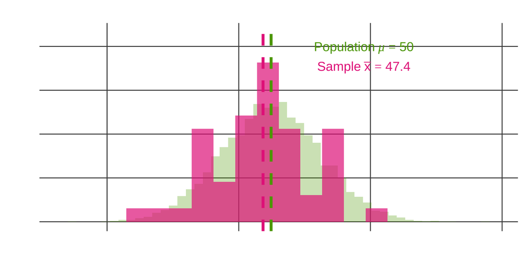

**The challenge**: Our sample mean (x̄) will differ from the true population mean (μ) due to sampling variability

## Three Questions Every Test Answers

**Every statistical test answers three related questions**:

1. **How different is our observed result from what we expected?**
   - If there’s no effect, how likely would we see this result by chance?
2. **How precise is our estimate?**
   - If we repeated the study, how much would our results vary?
3. **What’s a reasonable range for the true value?**
   - Given our data, what values are plausible for the population parameter?

**These three questions lead to**: t-statistics, standard errors, and confidence intervals

## Sampling Distributions: The Foundation

**Thought experiment**: What if we repeated our study 1,000 times?

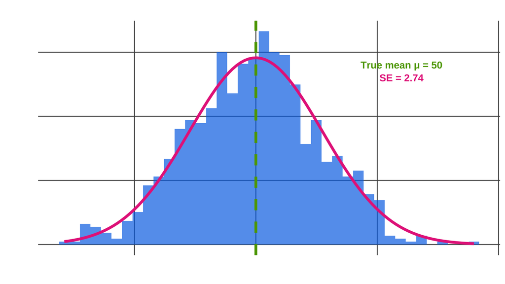

**Central Limit Theorem**: Sample means are normally distributed around the true mean, with spread determined by the **standard error**

## Standard Error: Quantifying Uncertainty

**Standard Error (SE)**: The standard deviation of the sampling distribution

$$SE = \frac{s}{\sqrt{n}}$$

**What determines SE?**

- **Sample size (n)**: Larger samples → smaller SE → more precision
- **Variability (s)**: More variable data → larger SE → less precision

**Small sample (n=10)**: - SE = 15 / √10 = 4.74 - Less precise

**Large sample (n=100)**: - SE = 15 / √100 = 1.50 - More precise

Precision increases with the square root of sample size. To halve the SE, you need 4× the sample size!

## Recall From Last Week: The t-Distribution

Last week ended with Gosset’s brewery problem. The short version:

- With small samples, the estimated SD (s) is an unreliable stand-in for the true SD — so we must be more cautious
- The **t-distribution** is the normal with **heavier tails**; its shape depends on degrees of freedom (df = n - 1)
- It approaches the normal as samples grow — nearly identical past n = 30
- The **critical value** is the bar |t| must clear: ±2.571 at df = 5, shrinking to ±1.96 in large samples

Today we put the t-distribution to work: one-sample, two-sample, and regression t-tests

One-Sample t-Test

## The Logic of Hypothesis Testing

**Research Question**: Is the population mean different from a hypothesized value?

**Example**: Is the average approval rating of the president different from 50%?

**Two competing hypotheses**:

- **Null Hypothesis (H₀)**: μ = 50 (no difference from hypothesized value)
- **Alternative Hypothesis (H₁)**: μ ≠ 50 (there is a difference)

**The logic**: Assume H₀ is true, then ask: “How surprising is our observed sample?”

## The t-Statistic

**Formula**:
$$t = \frac{\bar{x} - \mu_0}{s / \sqrt{n}}$$

**Components**:

- **$\bar{x}$**: Sample mean (what we observed)
- **$\mu_0$**: Hypothesized population mean (null hypothesis value)
- **$s / \sqrt{n}$**: Standard error (how much sample means vary)

**Interpretation**: The t-statistic tells us how many standard errors our sample mean is away from the hypothesized value

**Decision rule**: If |t| is large enough, we reject H₀

## Example: Presidential Approval Rating

```r
# One-sample t-test
approval_test <- t.test(approval_data$approval, mu = 50)
approval_test
```

```
    One Sample t-test

data:  approval_data$approval
t = -0.57806, df = 39, p-value = 0.5665
alternative hypothesis: true mean is not equal to 50
95 percent confidence interval:
 44.45271 53.08133
sample estimates:
mean of x
 48.76702
```

**What we found**:

- Sample mean: 48.8%
- Hypothesized: 50%
- Difference: -1.2%

**Statistical evidence**:

- t = -0.58
- p-value = 0.567
- **Conclusion**: Not significantly different from 50%

## Understanding the p-value

**What does p = 0.567 mean?**

If the true approval is 50%, there’s a 56.7% chance of observing a sample mean this far (or farther) from 50%.

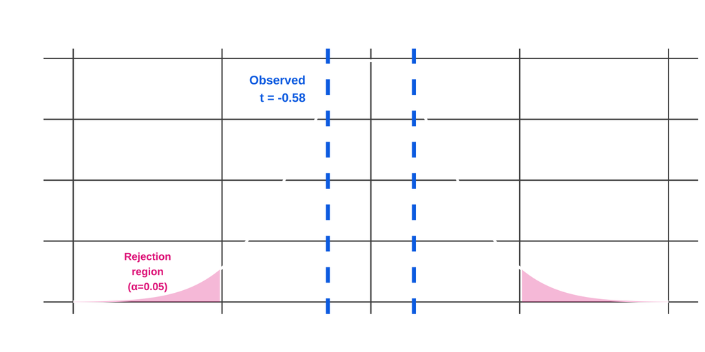

**Common mistake**: p = 0.567 does NOT mean “there’s a 56.7% chance H₀ is true”

Two-Sample t-Tests

## Comparing Two Groups: The Most Common Test

**Research questions**:

- Do democratic countries have higher GDP than autocracies?
- Do voters respond differently to negative vs. positive ads?
- Is voter turnout higher in battleground states?

**The workhorse of empirical research**: Most research questions boil down to comparing two groups

## Two-Sample t-Test: The Logic

**Null Hypothesis (H₀)**: μ₁ = μ₂ (no difference between groups)

**Alternative Hypothesis (H₁)**: μ₁ ≠ μ₂ (groups differ)

**The statistic**:
$$t = \frac{(\bar{x}_1 - \bar{x}_2) - 0}{\text{SE of difference}}$$

where:
$$\text{SE of difference} = \sqrt{\frac{s_1^2}{n_1} + \frac{s_2^2}{n_2}}$$

**Intuition**: How many standard errors apart are the two group means?

## Understanding the SE of Differences

**Why do we add the variances?**

The variability in the difference between two means depends on:

1. How variable Group 1 is (s₁²/n₁)
2. How variable Group 2 is (s₂²/n₂)

**Key insights**:

- Larger samples → smaller SE → easier to detect differences
- More variable data → larger SE → harder to detect differences
- The SE is driven by the *smaller* group — a large total n can’t rescue one tiny group

**Common mistake**: Thinking the SE of the difference equals the average of the two SEs. We add variances, not standard errors!

## Example 1: Get-Out-The-Vote Experiment

**Research Question**: Does a door-to-door canvassing campaign increase voter turnout?

**Design**:

- Randomly assigned 500 voters to treatment (n=250) or control (n=250)
- Measured whether each voter turned out

```r
# Compare turnout rates
gotv_experiment %>%
  group_by(treatment) %>%
  summarise(
    n = n(),
    mean_turnout = mean(turnout_pct),
    sd_turnout = sd(turnout_pct)
  )
```

```
# A tibble: 2 × 4
  treatment     n mean_turnout sd_turnout
  <chr>     <int>        <dbl>      <dbl>
1 Canvassed   250         48.8       50.1
2 Control     250         44.4       49.8
```

## GOTV Results

```r
# Two-sample t-test
gotv_test <- t.test(turnout_pct ~ treatment, data = gotv_experiment)
gotv_test
```

```
    Welch Two Sample t-test

data:  turnout_pct by treatment
t = 0.98514, df = 497.98, p-value = 0.325
alternative hypothesis: true difference in means between group Canvassed and group Control is not equal to 0
95 percent confidence interval:
 -4.375281 13.175281
sample estimates:
mean in group Canvassed   mean in group Control
                   48.8                    44.4
```

**What we found**:

- Control: 44.4% turnout
- Canvassed: 48.8% turnout
- **Difference: +4.4 percentage points**

**Statistical evidence**:

- t = 0.99
- p = 0.325
- **Conclusion**: the +4.4-point gap is not significant — it could easily be chance

## Example 2: Media Consumption and Political Knowledge

**Research Question**: Do people who regularly watch news have higher political knowledge than those who don’t?

**Data**: Survey of 200 people (10-point political knowledge scale)

```r
# Summary statistics
news_knowledge %>%
  group_by(watches_news) %>%
  summarise(
    n = n(),
    mean_knowledge = mean(knowledge_score),
    sd_knowledge = sd(knowledge_score),
    se_knowledge = sd_knowledge / sqrt(n)
  )
```

```
# A tibble: 2 × 5
  watches_news     n mean_knowledge sd_knowledge se_knowledge
  <chr>        <int>          <dbl>        <dbl>        <dbl>
1 No             113           5.95         2.12        0.199
2 Yes             87           7.20         2.14        0.229
```

## Media Consumption Results

```r
news_test <- t.test(knowledge_score ~ watches_news, data = news_knowledge)
news_test
```

```
    Welch Two Sample t-test

data:  knowledge_score by watches_news
t = -4.1389, df = 184.17, p-value = 5.306e-05
alternative hypothesis: true difference in means between group No and group Yes is not equal to 0
95 percent confidence interval:
 -1.8563327 -0.6578596
sample estimates:
 mean in group No mean in group Yes
         5.947870          7.204967
```

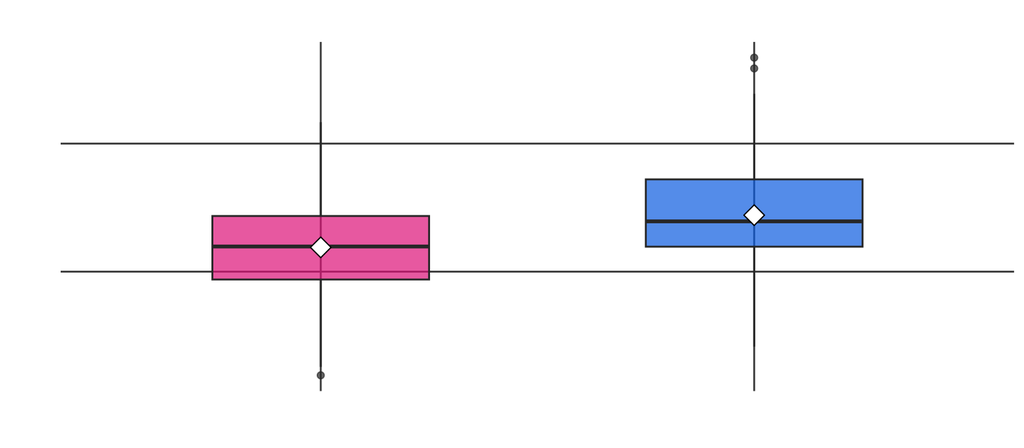

**Conclusion**: News watchers score 1.3 points higher on average (p < 0.001)

## Example 3: Income and Oil Resources

**Research Question**: Do developing countries with oil resources have different incomes than those without?

**Data**: 120 developing countries, GDP per capita

```r
# Test for income differences
oil_test <- t.test(gdp_per_capita ~ has_oil, data = oil_income)
oil_test
```

```
    Welch Two Sample t-test

data:  gdp_per_capita by has_oil
t = -9.3474, df = 31.728, p-value = 1.25e-10
alternative hypothesis: true difference in means between group No Oil and group Oil-Rich is not equal to 0
95 percent confidence interval:
 -9458.544 -6072.870
sample estimates:
  mean in group No Oil mean in group Oil-Rich
              6699.268              14464.975
```

## Oil Resources: Interpretation

**Results**:

- No oil: $6,699
- Oil-rich: $14,465
- **Difference: $7,766**
- t = -9.35
- p < 0.001

**Interpretation**:

- Highly significant difference
- Oil-rich countries have ~$7,766 higher GDP per capita
- But: correlation ≠ causation!
- Could be reverse causation, confounding, etc.

**Caution**: This is observational data. We cannot conclude that oil *causes* higher income without ruling out confounds

## Example 4: A Null Result

**Research Question**: Does having a college-educated parent affect political participation?

```r
participation_test <- t.test(participation ~ parent_college,
                            data = parent_participation)
participation_test
```

```
    Welch Two Sample t-test

data:  participation by parent_college
t = -1.8432, df = 147.18, p-value = 0.06731
alternative hypothesis: true difference in means between group No and group Yes is not equal to 0
95 percent confidence interval:
 -0.66138892  0.02302832
sample estimates:
 mean in group No mean in group Yes
         3.120681          3.439861
```

**Results**: No significant difference (t = -1.84, p = 0.067)

**Important lesson**: Null results are scientifically valuable! They tell us what factors DON’T matter

## When t-Tests Can Go Wrong

**Violations of assumptions**:

1. **Extreme outliers**: t-tests are robust to moderate outliers, but extreme outliers can be problematic
2. **Highly skewed data with small samples**:
   - With n < 15 and strong skew, consider alternatives
   - With n > 30, t-test is usually fine even with skewed data
3. **Very unequal variances**:
   - R’s `t.test()` uses Welch’s correction by default (good!)
   - Classical t-test assumes equal variances

**Good news**: The t-test is remarkably robust to violations with moderate sample sizes

Standard Error in Regression

## Regression Coefficients are Estimates

**Remember**: When we run a regression, we’re estimating population parameters from a sample

```r
# Simple regression: vote share on ad spending
model1 <- lm(vote_share ~ ad_spending, data = campaign_data)
tidy(model1)
```

```
# A tibble: 2 × 5
  term        estimate std.error statistic  p.value
  <chr>          <dbl>     <dbl>     <dbl>    <dbl>
1 (Intercept)  31.3      1.88         16.7 2.25e-30
2 ad_spending   0.0467   0.00365      12.8 1.40e-22
```

**The question**: If we collected a different sample, how much would this coefficient change?

## What is Standard Error in Regression?

**Standard Error of β̂**: Measures the precision of our coefficient estimate

$$SE(\hat{\beta}) = \text{How much } \hat{\beta} \text{ varies across samples}$$

**Interpretation**: If we repeated our study many times, the SE tells us how spread out our coefficient estimates would be

**Small SE**:

- High precision
- Confident in our estimate
- Estimate doesn’t vary much across samples

**Large SE**:

- Low precision
- Less confident in estimate
- Estimate varies a lot across samples

## Simulation: Understanding SE Visually

**What if we ran our campaign study 1,000 times?**

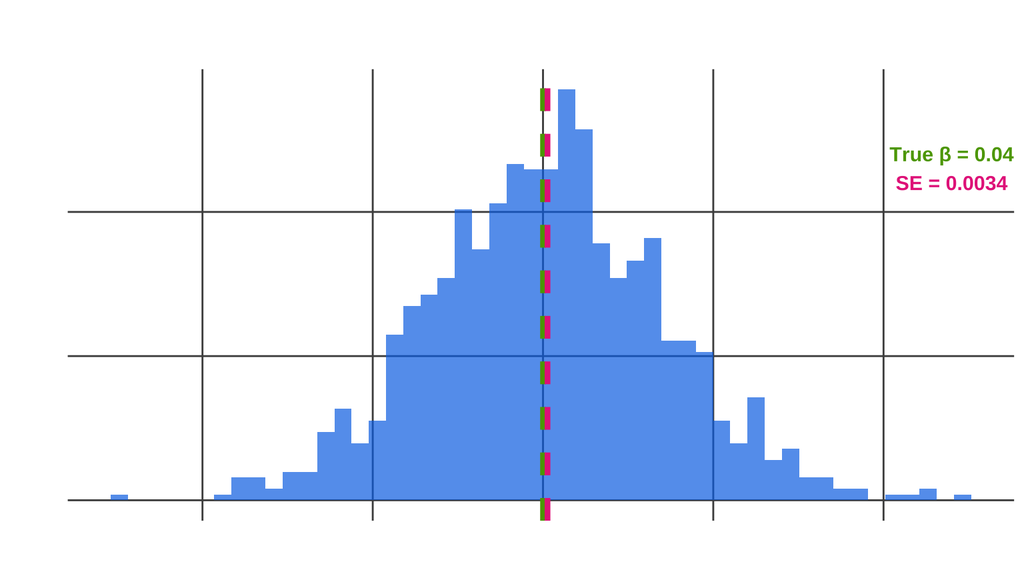

The SE is the standard deviation of this distribution: **0.0034**

## What Affects SE in Regression?

Three key factors determine the size of the standard error:

1. **Sample size (n)**: Larger samples → smaller SE
2. **Residual variance (σ²)**: More scatter around line → larger SE
3. **Variance in X**: More spread in predictor → smaller SE

Let’s demonstrate each with simulations…

## Factor 1: Sample Size Effect

**Doubling the sample size reduces SE by √2 ≈ 1.41**

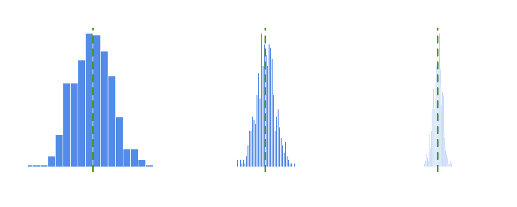

**Key insight**: To halve the SE, you need 4× the sample size!

## Factor 2: Residual Variance Effect

**More noise around the regression line → larger SE**

[figure not shown]

**Practical implication**: You have less control over this factor—it’s determined by your data

## Factor 3: Variance in X Effect

**More spread in your predictor → smaller SE**

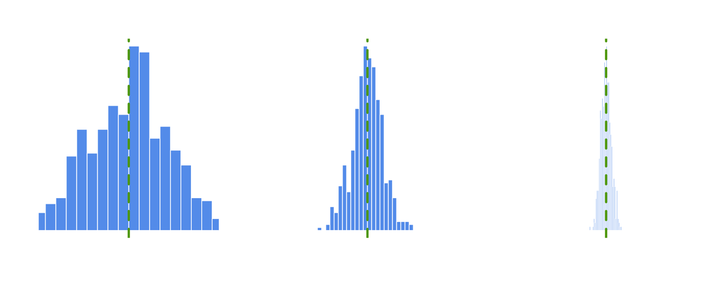

**Why?** More variation in X gives you more leverage to estimate the slope precisely

## Reading SE from Regression Output

```r
# Example: Education spending and test scores
set.seed(1111)
education_data <- tibble(
  district = 1:80,
  spending_per_student = rnorm(80, mean = 10000, sd = 2000),
  avg_test_score = 450 + 0.012 * spending_per_student + rnorm(80, mean = 0, sd = 35)
)

model_edu <- lm(avg_test_score ~ spending_per_student, data = education_data)
tidy(model_edu)
```

```
# A tibble: 2 × 5
  term                 estimate std.error statistic  p.value
  <chr>                   <dbl>     <dbl>     <dbl>    <dbl>
1 (Intercept)          438.      21.9         20.0  1.94e-32
2 spending_per_student   0.0143   0.00207      6.90 1.20e- 9
```

**Interpretation of spending coefficient**:

- **Estimate**: 0.0143 (For every $1 more spending → 0.0143 point increase in test scores)
- **Std.Error**: 0.00207 (This estimate could vary by ±0.00207 in repeated samples)

## SE and Statistical Significance: The Connection

**Rule of thumb**: If |coefficient| > ~2 × SE, it’s likely significant at α = 0.05

**Why does this work?**

$$t = \frac{\hat{\beta}}{SE(\hat{\beta})}$$

If |t| > ~2, then |β̂| > ~2 × SE

Critical value ≈ 1.96 for large samples

**Visual intuition**:

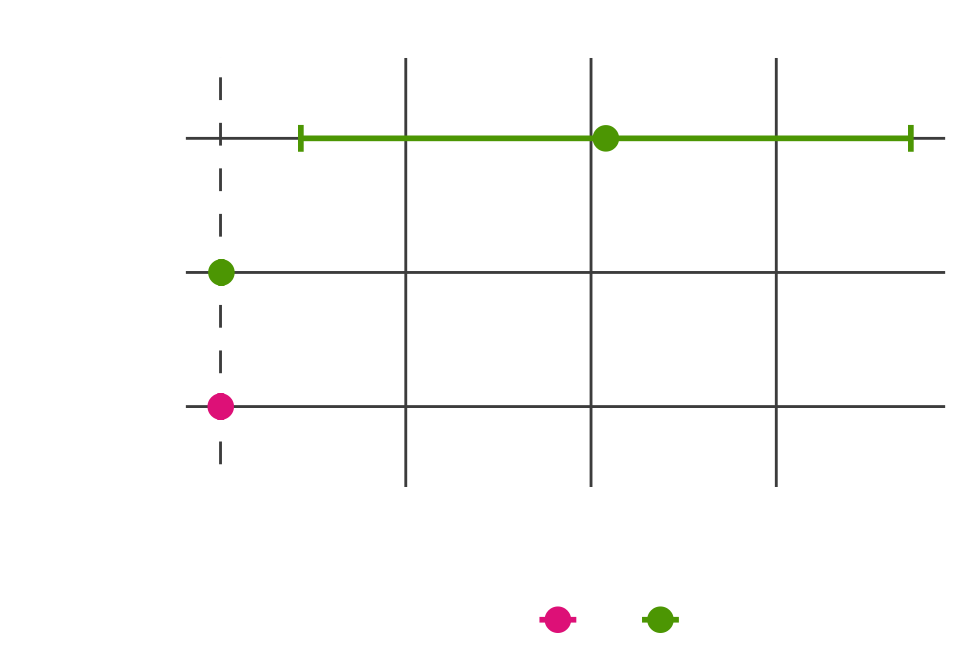

If CI crosses zero → not significant

t-Tests in Regression

## Same Machinery, New Question

So far the t-distribution has compared:

- a sample mean to a hypothesized value (**one-sample**)
- two group means to each other (**two-sample**)

Regression t-tests ask a new question with the **same machinery**:

- Not “is the mean different from zero?” but “is the **slope** different from zero?”
- Swap $\bar x$ and $SE(\bar x)$ for $\hat\beta$ and $SE(\hat\beta)$ — the logic (estimate ÷ SE, look up the t-tail) is identical

## Every Coefficient is a Hypothesis Test

When you run a regression, R automatically tests:

**H₀: β = 0** (no relationship between X and Y) **H₁: β ≠ 0** (there is a relationship)

Using the test statistic:
$$t = \frac{\hat{\beta} - 0}{SE(\hat{\beta})} = \frac{\hat{\beta}}{SE(\hat{\beta})}$$

**This is just a one-sample t-test applied to coefficients!**

## Example: Campaign Finance and Votes

```r
model_campaign <- lm(vote_share ~ campaign_spending + incumbent,
                     data = campaign_model_data)
tidy(model_campaign)
```

```
# A tibble: 3 × 5
  term              estimate std.error statistic  p.value
  <chr>                <dbl>     <dbl>     <dbl>    <dbl>
1 (Intercept)        27.4      1.11         24.7 3.39e-54
2 campaign_spending   0.0259   0.00140      18.5 3.98e-40
3 incumbent           8.01     0.763        10.5 1.39e-19
```

**For campaign_spending coefficient**:

- t = 18.46
- p < 0.001
- **Conclusion**: Campaign spending significantly predicts vote share (holding incumbency constant)

## Understanding “Conditional” Tests

**Simple regression**:

```r
# Just spending
model_simple <- lm(vote_share ~ campaign_spending,
                   data = campaign_model_data)
tidy(model_simple) %>% filter(term == "campaign_spending")
```

```
# A tibble: 1 × 5
  term              estimate std.error statistic  p.value
  <chr>                <dbl>     <dbl>     <dbl>    <dbl>
1 campaign_spending   0.0261   0.00185      14.1 3.39e-29
```

**t-test here**: Does spending predict votes?

**Multiple regression**:

```r
# Spending + incumbency
model_multiple <- lm(vote_share ~ campaign_spending + incumbent,
                     data = campaign_model_data)
tidy(model_multiple) %>% filter(term == "campaign_spending")
```

```
# A tibble: 1 × 5
  term              estimate std.error statistic  p.value
  <chr>                <dbl>     <dbl>     <dbl>    <dbl>
1 campaign_spending   0.0259   0.00140      18.5 3.98e-40
```

**t-test here**: Does spending predict votes **after controlling for incumbency**?

**Critical distinction**: In multiple regression, each t-test is conditional on all other variables in the model

## t-Tests ARE Regression!

**A two-sample t-test is just a regression with a binary predictor**

**Method 1: t-test**

```r
t.test(outcome ~ treatment,
       data = treatment_data,
       var.equal = TRUE)
```

```
    Two Sample t-test

data:  outcome by treatment
t = -3.3887, df = 98, p-value = 0.001013
alternative hypothesis: true difference in means between group Control and group Treatment is not equal to 0
95 percent confidence interval:
 -9.856375 -2.575912
sample estimates:
  mean in group Control mean in group Treatment
               41.90859                48.12474
```

**Method 2: Regression**

```r
lm(outcome ~ treatment_dummy,
   data = treatment_data) %>%
  tidy()
```

```
# A tibble: 2 × 5
  term            estimate std.error statistic  p.value
  <chr>              <dbl>     <dbl>     <dbl>    <dbl>
1 (Intercept)        41.9       1.30     32.3  4.68e-54
2 treatment_dummy     6.22      1.83      3.39 1.01e- 3
```

**Notice**: Same t-statistic (3.39), same p-value (0.001)!

## Practice: Interpreting Regression t-Tests

```r
# Predicting voter turnout
turnout_model <- lm(turnout ~ age + income + education_years,
                    data = voter_model_data)
tidy(turnout_model)
```

```
# A tibble: 4 × 5
  term                estimate  std.error statistic p.value
  <chr>                  <dbl>      <dbl>     <dbl>   <dbl>
1 (Intercept)      0.0439      0.201          0.218  0.828
2 age              0.00551     0.00225        2.45   0.0152
3 income          -0.000000227 0.00000174    -0.130  0.897
4 education_years  0.0183      0.0109         1.69   0.0929
```

**Questions**:

1. Which variables significantly predict turnout?
2. What does the age t-statistic mean, in words?
3. Why is income not significant?

Segment B — Confidence Intervals

## From t-Statistics to Confidence Intervals

**But researchers want to know**: What’s the *range* of plausible values?

**We’ve learned**:

- t-statistics tell us “how many SEs away from zero”
- p-values tell us “probability of this result if H₀ true”
- Both give a yes/no verdict about a single null value

**Why CIs are useful**:

- Give a sense of precision (narrow vs. wide)
- Communicate effect size AND uncertainty
- More intuitive than p-values for many audiences

**Confidence Interval**: Provides a range of values that likely contain the true population parameter

## One Study Among Many Possible Studies

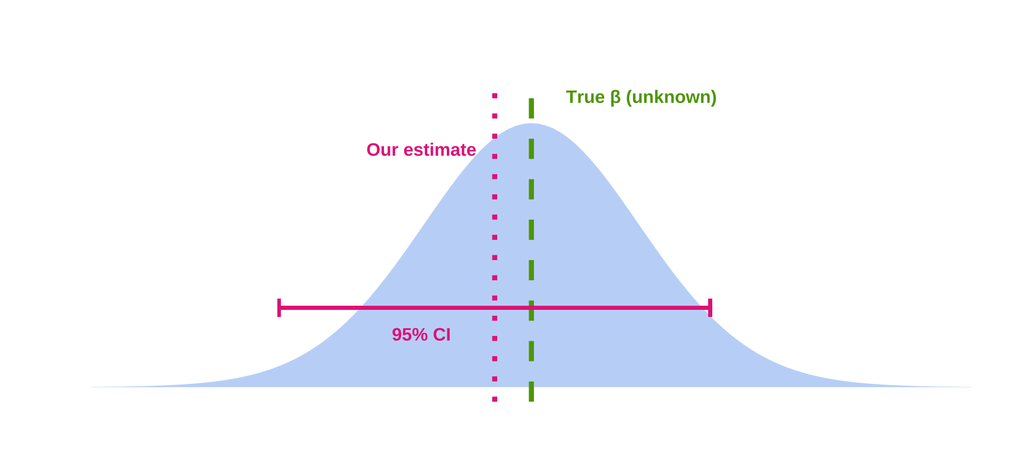

**Key insight**: Our estimate (β̂) is just one draw from a sampling distribution

- If we repeated this study many times, 95% of our CIs would contain the true β
- We don’t know if THIS particular CI does, but we’re “95% confident”

## Constructing a 95% CI

**The formula**:
$$\text{CI} = \hat{\beta} \pm t_{\text{critical}} \times SE(\hat{\beta})$$

**Three components**:

1. **Point estimate** (β̂): Our best guess from the sample
2. **Critical value** (t<sub>critical</sub>): Comes from the t-distribution
   - Depends on: confidence level + degrees of freedom
   - For 95% CI: captures middle 95% of t-distribution
3. **Standard error** (SE): Measures sampling variability

**Think of it as**: “best guess” ± “margin of error” — the same recipe works for coefficients, means, and mean differences

## Critical Values

**Where does t<sub>critical</sub> come from?**

For a 95% CI:

- We want to capture the middle 95% of the t-distribution
- This leaves 2.5% in each tail (α/2 = 0.025)
- The critical value is the t-value where 97.5% of the distribution is below it

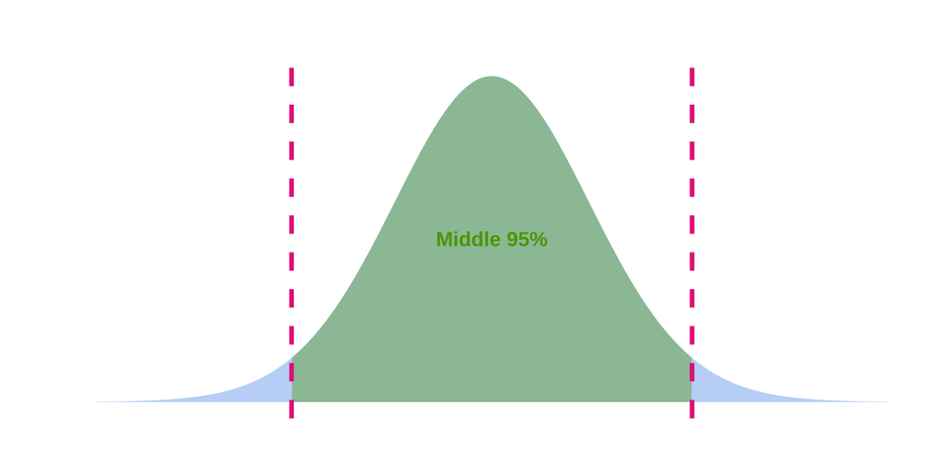

**Key point**: Critical values get smaller as sample size increases (df ↑)

## Finding Critical Values in R

**Use the `qt()` function**: “quantile of the t-distribution”

```r
# Small sample (n=40, df=38)
qt(0.975, df = 38)
```

```
[1] 2.024394
```

```r
# Medium sample (n=100, df=98)
qt(0.975, df = 98)
```

```
[1] 1.984467
```

```r
# Large sample (n=500, df=498)
qt(0.975, df = 498)
```

```
[1] 1.964739
```

```r
# Very large sample (approaches 1.96)
qt(0.975, df = 10000)
```

```
[1] 1.960201
```

## Step-by-Step: Calculating a 95% CI Manually

**Let’s calculate the CI for the voter turnout study by hand**:

```r
# Step 1: Get coefficient and SE
coef_val <- coef(model_voter_small)[2]
se_val <- summary(model_voter_small)$coefficients[2, 2]

# Step 2: Find critical value (df = 38)
t_crit <- qt(0.975, df = 38)

# Step 3: Calculate margin of error
margin <- t_crit * se_val

# Step 4: Calculate CI bounds
lower <- coef_val - margin
upper <- coef_val + margin

c(lower, upper)
```

```
canvassing_contacts canvassing_contacts
         0.01789438          1.42097525
```

**Our manual 95% CI**: [0.018, 1.421]

## Getting CIs from Regression (The Easy Way)

**R does all this for you with `confint()`!**

```r
tidy(model_edu)
```

```
# A tibble: 2 × 5
  term                 estimate std.error statistic  p.value
  <chr>                   <dbl>     <dbl>     <dbl>    <dbl>
1 (Intercept)          65.9      3.58         18.4  1.58e-33
2 spending_per_student  0.00136  0.000285      4.77 6.37e- 6
```

```r
confint(model_edu)
```

```
                            2.5 %       97.5 %
(Intercept)          5.874713e+01 72.966207980
spending_per_student 7.944833e-04  0.001925668
```

**Interpretation for spending_per_student**:

- 95% CI: [0.00079, 0.00193]
- We’re 95% confident that each $1 increase in spending increases test scores by between 0.00079 and 0.00193 points

**Connection to significance**: If 95% CI excludes 0, then p < 0.05

## Different Confidence Levels: 90%, 95%, 99%

**The trade-off**: Confidence vs. Precision

Higher confidence → Need wider interval

```r
# 90% CI
confint(model_voter_small, level = 0.90)
```

```
                           5 %      95 %
(Intercept)         35.6060628 54.568761
canvassing_contacts  0.1351784  1.303691
```

```r
# 95% CI (default)
confint(model_voter_small, level = 0.95)
```

```
                          2.5 %    97.5 %
(Intercept)         33.70277006 56.472054
canvassing_contacts  0.01789438  1.420975
```

```r
# 99% CI
confint(model_voter_small, level = 0.99)
```

```
                         0.5 %    99.5 %
(Intercept)         29.8383499 60.336474
canvassing_contacts -0.2202376  1.659107
```

## Understanding Different Confidence Levels

**How critical values change**:

```r
qt(0.95, df = 38)   # 90% CI
```

```
[1] 1.685954
```

```r
qt(0.975, df = 38)  # 95% CI
```

```
[1] 2.024394
```

```r
qt(0.995, df = 38)  # 99% CI
```

```
[1] 2.711558
```

```r
qt(0.9995, df = 38) # 99.9% CI
```

```
[1] 3.565678
```

**Notice**: As confidence increases, critical value increases

Three Signals

## SE, t-statistic, p-value, and CI: All Connected

Let’s use our education spending example to show how they all tell the same story:

```r
# Get all the pieces
tidy(model_edu)
```

```
# A tibble: 2 × 5
  term                 estimate std.error statistic  p.value
  <chr>                   <dbl>     <dbl>     <dbl>    <dbl>
1 (Intercept)          65.9      3.58         18.4  1.58e-33
2 spending_per_student  0.00136  0.000285      4.77 6.37e- 6
```

```r
confint(model_edu)
```

```
                            2.5 %       97.5 %
(Intercept)          5.874713e+01 72.966207980
spending_per_student 7.944833e-04  0.001925668
```

## Deriving t and p by Hand

```r
# 1. t-statistic comes from coefficient and SE
t_calculated <- coef(model_edu)[2] / summary(model_edu)$coefficients[2, 2]
t_calculated
```

```
spending_per_student
            4.772034
```

```r
# Compare to reported t-statistic
summary(model_edu)$coefficients[2, 3]
```

```
[1] 4.772034
```

```r
# 2. p-value comes from t-statistic
p_calculated <- 2 * (1 - pt(abs(t_calculated), df = 98))
p_calculated
```

```
spending_per_student
        6.369954e-06
```

```r
# Compare to reported p-value
summary(model_edu)$coefficients[2, 4]
```

```
[1] 6.369954e-06
```

## Deriving the CI by Hand

**The CI comes from the same ingredients**:

```r
# 3. CI uses coefficient, SE, and critical value
beta_hat <- coef(model_edu)[2]
se <- summary(model_edu)$coefficients[2, 2]
t_crit_95 <- qt(0.975, df = 98)

# Calculate CI manually
ci_lower <- beta_hat - t_crit_95 * se
ci_upper <- beta_hat + t_crit_95 * se

c(ci_lower, ci_upper)
```

```
spending_per_student spending_per_student
        0.0007944833         0.0019256681
```

```r
# Compare to confint()
confint(model_edu)[2, ]
```

```
       2.5 %       97.5 %
0.0007944833 0.0019256681
```

All these statistics are derived from the same underlying information.

## The Key Equivalence: CI and p-value

**For a 95% CI and α = 0.05 test**:

**If 95% CI excludes 0**:

- p < 0.05 (significant)
- |t| > ~1.96
- Reject H₀

**If 95% CI includes 0**:

- p > 0.05 (not significant)
- |t| < ~1.96
- Fail to reject H₀

**Example** (create a non-sig result):

- CI: [-0.276, 0.375]
- Includes 0 ✓
- p = 0.757 > 0.05 ✓
- |t| = 0.31 < 1.96 ✓

## n = 40 vs. n = 500

**Let’s compare small (n=40) vs. large (n=500) samples with same effect**:

**Small sample (n=40)**:

```r
tidy(model_voter_small)
```

```
# A tibble: 2 × 5
  term                estimate std.error statistic       p.value
  <chr>                  <dbl>     <dbl>     <dbl>         <dbl>
1 (Intercept)           45.1       5.62       8.02 0.00000000108
2 canvassing_contacts    0.719     0.347      2.08 0.0447
```

```r
confint(model_voter_small)
```

```
                          2.5 %    97.5 %
(Intercept)         33.70277006 56.472054
canvassing_contacts  0.01789438  1.420975
```

**Large sample (n=500)**:

```r
tidy(model_voter_large)
```

```
# A tibble: 2 × 5
  term                estimate std.error statistic   p.value
  <chr>                  <dbl>     <dbl>     <dbl>     <dbl>
1 (Intercept)           43.7      1.43        30.6 1.88e-116
2 canvassing_contacts    0.919    0.0910      10.1 5.98e- 22
```

```r
confint(model_voter_large)
```

```
                         2.5 %    97.5 %
(Intercept)         40.9106752 46.525789
canvassing_contacts  0.7404609  1.098046
```

## Visualizing Uncertainty with CIs

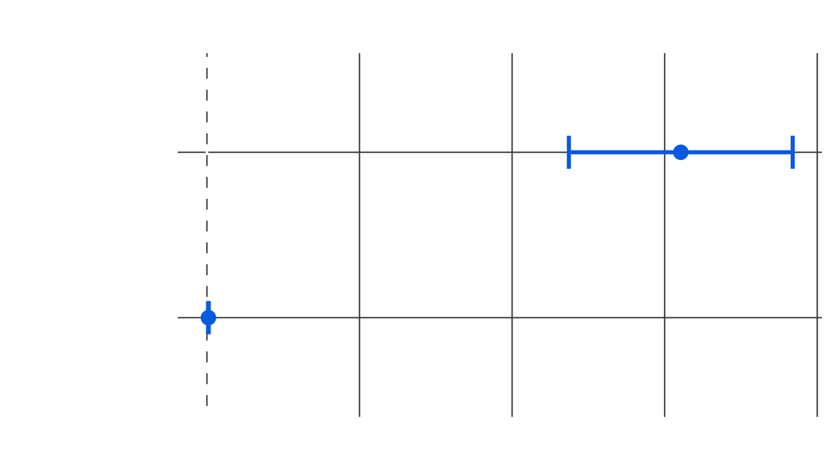

## What Does “95% Confident” Really Mean?

**Common misinterpretation** ❌: “There’s a 95% chance the true parameter is in this interval”

**Correct interpretation** ✅: “If we repeated this study 100 times and calculated 100 CIs, approximately 95 would contain the true parameter”

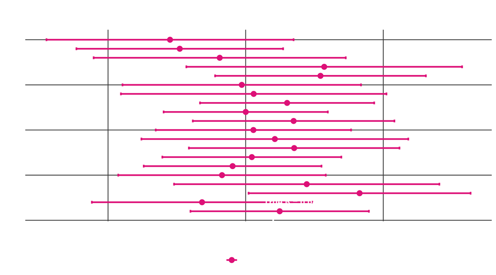

**The parameter is fixed, the interval is random!**

## Comparing Confidence Levels

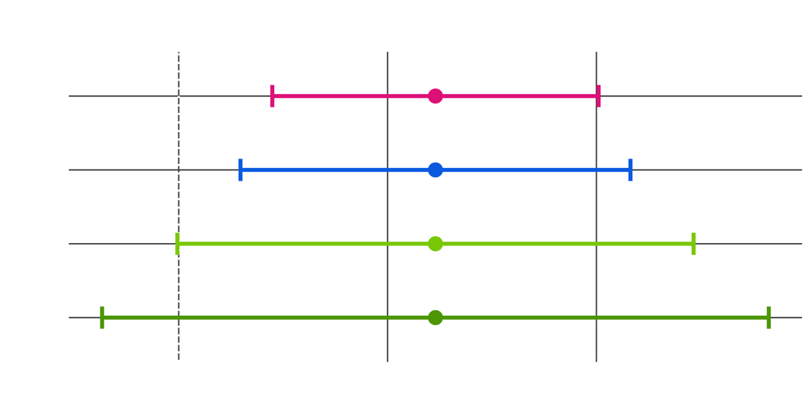

**The trade-off**: Higher confidence requires wider intervals

## CI vs. p-value: Two Perspectives on Uncertainty

**p-value**:

- Single number
- “How surprising is this result?”
- Binary thinking (significant vs. not)
- Doesn’t tell you about effect size

**Example**: p = 0.03

- Significant, but…
- Is the effect large or small?
- How precise is our estimate?

**Confidence Interval**:

- Range of values
- “What are plausible values?”
- Communicates precision
- Includes effect size information

**Example**: CI = [0.002, 0.048]

- Significant (excludes 0)
- Effect is small
- Fairly precise estimate

**Best practice**: Report CIs

How to Write Up Confidence Intervals

## Bad vs. Good: Writing About Results

**Example**: Public opinion study on age and policy support

```
# A tibble: 3 × 5
  term            estimate std.error statistic       p.value
  <chr>              <dbl>     <dbl>     <dbl>         <dbl>
1 (Intercept)       34.6      5.58        6.20 0.00000000543
2 age                0.394    0.0622      6.34 0.00000000261
3 education_years    2.09     0.339       6.17 0.00000000634
```

```
                     2.5 %     97.5 %
(Intercept)     23.5604250 45.6105995
age              0.2715785  0.5173461
education_years  1.4194485  2.7576928
```

Let’s look at the age coefficient…

## Writing About CIs: What NOT to Do

**❌ Bad Example 1: Numbers without context**

> “The coefficient for age was 0.39 with a 95% CI of [0.27, 0.52].”

**Problems**:

- No interpretation of what this means
- No context about significance
- No discussion of practical importance
- Just reporting numbers

**❌ Bad Example 2: Overconfident claims**

> “Age causes a 0.39 point increase in policy support.”

**Problems**:

- No acknowledgment of uncertainty

## Writing About CIs: What NOT to Do (continued)

**❌ Bad Example 3: Misinterpreting the CI**

> “There is a 95% probability that the true effect of age is between 0.27 and 0.52.”

**Problems**:

- Wrong! The true parameter is fixed, not random
- This treats the parameter as having a probability distribution
- Correct interpretation: If we repeated this study 100 times, ~95 of our CIs would contain the true value

**❌ Bad Example 4: Ignoring uncertainty**

> “The effect is 0.39, so each year of age increases support by about 0.4 points.”

**Problems**:

- Treats point estimate as the truth
- Ignores the range in the CI [0.27, 0.52]
- Doesn’t communicate precision

## Writing About CIs: The Good Way

**✅ Good Example: Complete and contextualized**

**Why it’s good**:

- States the finding clearly
- Reports all key statistics
- Interprets the effect size
- Acknowledges uncertainty and precision of estimate
- Discusses practical significance
- Uses appropriate (non-causal) language

## The Template for Writing Up CIs

**Follow this structure**:

1. **State the direction and significance**
   - “X was positively/negatively/not significantly associated with Y”
2. **Report the statistics**
   - “(β = *, 95% CI: [*,* ], t(df) =* , p = ___)”
3. **Interpret the effect size**
   - “Each unit increase in X was associated with a ___-unit change in Y”
4. **Comment on precision**
   - “The confidence interval is narrow/wide, suggesting high/low precision”
5. **Discuss practical significance**
   - “This represents a small/moderate/large effect in practical terms…”
6. **Add context**
   - Compare to other studies, baseline values, or meaningful benchmarks

## More Examples: Education and Policy Support

**For the education coefficient**:

```
Education coefficient: 2.09
95% CI: [1.42, 2.76]
t = 6.17, p < 0.001
```

**✅ Good write-up**:

> “Educational attainment showed a strong positive relationship with policy support (β = 2.09, 95% CI: [1.42, 2.76], t(147) = 6.17, p < 0.001). Each additional year of education was associated with a 2.09-point increase in policy support. This effect is both statistically and practically significant: the difference between a high school graduate (12 years) and a college graduate (16 years) would be approximately 8.4 points on the 100-point scale. The relatively narrow confidence interval indicates this estimate is quite precise.”

## Writing Up Non-Significant Results

**Important**: Non-significant ≠ “no effect”

**Example**: Small pilot study

```r
tidy(pilot_model)
```

```
# A tibble: 2 × 5
  term        estimate std.error statistic  p.value
  <chr>          <dbl>     <dbl>     <dbl>    <dbl>
1 (Intercept)    53.5       4.27    12.5   9.31e-12
2 treatment       5.27      6.16     0.855 4.01e- 1
```

```r
confint(pilot_model)
```

```
                2.5 %   97.5 %
(Intercept) 44.655345 62.31844
treatment   -7.478291 18.01618
```

## Writing About Non-Significant Results (continued)

**❌ Bad write-up**:

> “Treatment had no effect on the outcome (p = 0.4).”

**Problems**:

- Conflates “not significant” with “no effect”
- Ignores the point estimate

**✅ Good write-up**:

> “The treatment group scored 5.3 points higher than the control group, but this difference was not statistically significant (β = 5.3, 95% CI: [-7.5, 18], t(23) = 0.86, p = 0.4). However, the confidence interval is very wide, ranging from -7.5 to 18, and includes effect sizes that would be practically meaningful. Thus, we cannot conclude there is no effect; rather, this pilot study lacked the precision to detect an effect if one exists. A larger study would be needed to estimate the treatment effect more precisely.”

## Multiple Predictors: Reporting Strategy

**When you have multiple predictors**, organize by importance:

**Organization**:

1. Start with overview
2. Most important/largest effect first
3. Provide full stats for each
4. Use “holding X constant” language for multiple regression

Common Pitfalls

## Pitfall 1: Confusing Statistical and Practical Significance

**Scenario**: Large sample study finds statistically significant effect

```r
large_model <- lm(outcome ~ intervention, data = large_sample)
tidy(large_model)
```

```
# A tibble: 2 × 5
  term         estimate std.error statistic    p.value
  <chr>           <dbl>     <dbl>     <dbl>      <dbl>
1 (Intercept)    50.0      0.0426   1175.   0
2 intervention    0.284    0.0601      4.73 0.00000224
```

**Problem**:

- Significant (p < 0.001) ✅
- But effect is tiny: β = 0.28 (0.6% change from baseline of 50) ⚠️
- With n=10,000, we can detect trivially small effects

**Lesson**: Statistical significance ≠ practical importance. Always consider effect size!

## Pitfall 2: Ignoring Confidence Intervals

**Scenario**: Two studies on the same topic

**Study A** (n=50):

- β̂ = 5.2
- SE = 2.8
- p = 0.07 (not significant)
- 95% CI: [-0.4, 10.8]

**Study B** (n=500):

- β̂ = 5.1
- SE = 0.9
- p < 0.001 (significant)
- 95% CI: [3.3, 6.9]

**Key insight**: Both studies found similar effect sizes (~5), but Study A was underpowered

**Lesson**: A non-significant result doesn’t mean “no effect” — it might just mean insufficient precision

## Pitfall 3: p-Hacking and Multiple Testing

**The problem**: Testing many variables increases your chance of finding a “significant” result by chance alone

**Example**: A researcher tests 20 different predictors of voting behavior

```
# A tibble: 7 × 2
  predictor    p_value
  <chr>          <dbl>
1 shoe_size      0.032
2 coffee_cups    0.087
3 plant_count    0.143
4 siblings       0.219
5 pets           0.267
6 sleep_hours    0.301
7 commute_time   0.358
```

```
# A tibble: 7 × 2
  predictor     p_value
  <chr>           <dbl>
1 age             0.412
2 income          0.445
3 education       0.501
4 tv_hours        0.538
5 social_media    0.576
6 exercise_freq   0.614
7 vacation_days   0.652
```

```
# A tibble: 6 × 2
  predictor          p_value
  <chr>                <dbl>
1 books_read           0.689
2 movie_pref           0.721
3 morning_person       0.758
4 fast_food            0.803
5 concert_attendance   0.841
6 cooking_skill        0.879
```

**Finding**: 1 out of 20 predictors is “significant” (p < 0.05)

- **Shoe size** appears to predict voting (p = 0.032) — but it’s a false positive!
- **All 20 variables are pure random noise with NO true relationship to voting**

With α = 0.05 and 20 tests, we expect 20 × 0.05 = 1 false positive on average

## Pitfall 4: Overinterpreting Non-Significant Results

**Example**: Small pilot study (n=20)

```r
small_model <- lm(outcome ~ treatment, data = small_study)
tidy(small_model, conf.int = TRUE)
```

```
# A tibble: 2 × 7
  term        estimate std.error statistic  p.value conf.low conf.high
  <chr>          <dbl>     <dbl>     <dbl>    <dbl>    <dbl>     <dbl>
1 (Intercept)    47.5       3.07     15.5  7.81e-12    41.1       54.0
2 treatment       6.13      4.35      1.41 1.76e- 1    -3.01      15.3
```

- β̂ = 6.1 (large effect!)
- But p = 0.18 (not significant)
- 95% CI: [-3, 15.3] — very wide, crosses zero
- **Interpretation**: Study was underpowered, not that effect doesn’t exist

**Lesson**: “Absence of evidence is not evidence of absence”

## Pitfall 5: Assuming Causal Interpretation

**Example**: Observational study finds education → income relationship

```r
# Observational data
obs_model <- lm(annual_income ~ college_degree, data = education_income_pit)
tidy(obs_model)
```

```
# A tibble: 2 × 5
  term              estimate std.error statistic  p.value
  <chr>                <dbl>     <dbl>     <dbl>    <dbl>
1 (Intercept)         46762.     1129.      41.4 1.78e-99
2 college_degreeYes   18984.     1693.      11.2 6.41e-23
```

**Problem**: Many confounders could explain this — family background, innate ability, social networks, geography.

**Lesson**: Statistical significance doesn’t imply causation.

## Reporting Checklist

**Every result you report should include**:

1. **Effect size**: the actual coefficient or difference
2. **Uncertainty**: SE or 95% CI (prefer the CI)
3. **Substantive interpretation**: what it means in context — and whether it *matters*

**Pro tip**: Lead with the substantive interpretation, then give the statistics in parentheses

**Example of good reporting**:

> “Canvassing increased voter turnout by 9 percentage points (95% CI: [2, 16]). This represents a practically significant boost that could influence election outcomes in competitive races.”

**Golden rule**: Tell a complete story with your statistics, not just report numbers

## Key Takeaways: What You Can Now Do

After this week you can:

- Construct and interpret a 95% (or 90%, 99%) confidence interval, by hand and with R
- Connect a CI to a hypothesis test: a 95% CI that excludes zero is equivalent to *p* < 0.05
- Reason about how sample size and SD jointly drive interval width (precision scales with √n)
- Move through the full empirical toolkit: design → description → regression → inference
- Write up an empirical result with both an effect size and a measure of uncertainty

Looking Ahead

## In Our Next Class

**Final Preparation & Review**

- Integrating design, description, regression, and inference
- Worked, exam-style problems
- Comprehensive review for the final